# data602 assignment4

jim lung

11-09-2017

# data602 assignment4

Deliverable: A url to a private repository on Github with the R script

Note: Docker image is not required for assignment #4

Take at least two of the time-series analytics performed in assignment #2 (listed below) and redo it in R. The time-series you can choose from are

5 day moving average 20 day moving average 5 day moving standard deviation 20 day moving standard deviation Bollinger bands 2 standard deviation Daily returns % Daily return mean % Price range for the day (bars) Daily price difference Distribution of prices (Gaussian distribution, aka bell curve)

Load the data that is sitting on a publicly available site via a URL (i.e. Dropbox, S3, public Github - only the data can be public), the data does not need to be in a database and can be static. The larger the dataset the better. Feel free to add your own time-series in addition to choosing 2 from above.

For this assignment, a Docker image is not required, only a link to a private Github repo containing the R script that can be executed and produces results without any setup

## Scraping and analysis:

```r
library(rvest)
library(RCurl)
library(XML)
```

## Create function for scraping data from web

```r
ddd <- function(i){


hkurl <- i

'ratings' <- function(hkurl)
  {
  require(XML)

hdoc <- getURLContent(hkurl)

# find all tables in webpage
hktables <- readHTMLTable(hdoc)

# find largest table and return as dataframe
columns <- unlist(lapply(hktables, function(t) dim(t)[2]))

df <- hktables[[max(columns)]]

return(df)
}

seriess <- ratings(hkurl)
colnames(seriess) <- c("Date","Open","High","Low","Close","Volume")
seriess
return(seriess)
}
```

## Create Dataframe by using function

```r
# Real time data for aapl
aapl3 <- ddd('http://www.nasdaq.com/symbol/aapl/historical')
head(aapl3)
```

```
##         Date   Open   High      Low  Close     Volume
## 1
## 2 11/24/2017  175.1  175.5 174.6459 174.97 14,026,670
## 3 11/22/2017 173.36    175   173.05 174.96 25,558,680
## 4 11/21/2017 170.78  173.7   170.78 173.14 25,047,130
## 5 11/20/2017 170.29 170.56   169.56 169.98 16,041,550
## 6 11/17/2017 171.04 171.39   169.64 170.15 21,884,010
```

```r
# Real time data for amzn
amzn3 <- ddd('http://www.nasdaq.com/symbol/amzn/historical')
head(amzn3)
```

```
##         Date    Open    High       Low   Close    Volume
## 1
## 2 11/24/2017  1160.7 1186.84    1160.7    1186 3,528,011
## 3 11/22/2017    1141 1160.27      1141 1156.16 3,549,453
## 4 11/21/2017 1132.86    1140    1128.2 1139.49 2,461,416
## 5 11/20/2017 1129.77 1133.42   1122.55 1126.31 2,146,183
## 6 11/17/2017 1138.28  1138.8 1125.8101 1129.88 2,360,174
```

```r
# Real time data for intc
intc3 <- ddd('http://www.nasdaq.com/symbol/intc/historical')
head(intc3)
```

```
##         Date  Open   High    Low Close     Volume
## 1
## 2 11/24/2017 44.55 44.775  44.43 44.75  6,465,815
## 3 11/22/2017 44.94  44.95 44.535 44.65 19,526,000
## 4 11/21/2017 44.72  45.22  44.71 44.94 21,761,970
## 5 11/20/2017 44.73 45.115   44.5 44.62 22,375,710
## 6 11/17/2017  45.5  45.62  44.62 44.63 63,190,520
```

```r
# Real time data for msft
msft3 <- ddd('http://www.nasdaq.com/symbol/msft/historical')
head(msft3)
```

```
##         Date  Open  High   Low Close     Volume
## 1
## 2 11/24/2017 83.01 83.43 82.78 83.26  7,425,603
## 3 11/22/2017 83.83  83.9 83.04 83.11 20,550,600
## 4 11/21/2017 82.74 83.84 82.74 83.72 21,195,610
## 5 11/20/2017  82.4 82.59 82.25 82.53 16,128,540
## 6 11/17/2017 83.12 83.12 82.24  82.4 22,075,340
```

```r
# Real time data for snap
snap3 <- ddd('http://www.nasdaq.com/symbol/snap/historical')
head(snap3)
```

```
##         Date  Open  High   Low Close     Volume
## 1
## 2 11/24/2017 12.67 13.02 12.67 12.97 12,772,780
## 3 11/22/2017 12.35 12.64 12.35 12.62 14,009,750
## 4 11/21/2017 12.52 12.59 12.32 12.34 18,962,990
## 5 11/20/2017  13.1 13.11 12.29 12.41 30,650,100
## 6 11/17/2017  12.6 13.01 12.51 12.99 17,549,950
```

## Replace text of today and remove comma

```r
# Get the text of today
library(lubridate)
date <- today()
newdate <- strptime(as.character(date), "%Y-%m-%d")
txtdate <- format(newdate, "%m/%d/%Y")
txtdate
```

```
## [1] "11/26/2017"
```

```r
# remove comma fuction
removeComma= function(s) {gsub(",", "", s, fixed = TRUE)}
```

## Function of calcuation of analysis

```r
abc <- function(z){
#colnames(z) <- c("Date","Open","High","Low","Close","Volume")
z$Date <- as.character(z$Date)
z$Open <- round(as.numeric(as.character(z$Open)),2)
z$High <- round(as.numeric(as.character(z$High)),2)
z$Low <- round(as.numeric(as.character(z$Low)),2)
z$Close <- round(as.numeric(as.character(z$Close)),2)
z$Volume <- as.numeric(as.character(removeComma(z$Volume)))
z[1,1] <- txtdate

z$change <- z$Close - z$Open
z$rating_change <- z$change / z$Open
z$date_range <- z$High - z$Low
z
}


aapl3 <- abc(aapl3)
head(aapl3)
```

```
##         Date   Open   High    Low  Close   Volume change rating_change
## 1 11/26/2017     NA     NA     NA     NA       NA     NA            NA
## 2 11/24/2017 175.10 175.50 174.65 174.97 14026670  -0.13 -0.0007424329
## 3 11/22/2017 173.36 175.00 173.05 174.96 25558680   1.60  0.0092293493
## 4 11/21/2017 170.78 173.70 170.78 173.14 25047130   2.36  0.0138189484
## 5 11/20/2017 170.29 170.56 169.56 169.98 16041550  -0.31 -0.0018204240
## 6 11/17/2017 171.04 171.39 169.64 170.15 21884010  -0.89 -0.0052034612
##   date_range
## 1         NA
## 2       0.85
## 3       1.95
## 4       2.92
## 5       1.00
## 6       1.75
```

```r
amzn3 <- abc(amzn3)
head(amzn3)
```

```
##         Date    Open    High     Low   Close  Volume change rating_change
## 1 11/26/2017      NA      NA      NA      NA      NA     NA            NA
## 2 11/24/2017 1160.70 1186.84 1160.70 1186.00 3528011  25.30   0.021797191
## 3 11/22/2017 1141.00 1160.27 1141.00 1156.16 3549453  15.16   0.013286591
## 4 11/21/2017 1132.86 1140.00 1128.20 1139.49 2461416   6.63   0.005852444
## 5 11/20/2017 1129.77 1133.42 1122.55 1126.31 2146183  -3.46  -0.003062570
## 6 11/17/2017 1138.28 1138.80 1125.81 1129.88 2360174  -8.40  -0.007379555
##   date_range
## 1         NA
## 2      26.14
## 3      19.27
## 4      11.80
## 5      10.87
## 6      12.99
```

```r
intc3 <- abc(intc3)
head(intc3)
```

```
##         Date  Open  High   Low Close   Volume change rating_change
## 1 11/26/2017    NA    NA    NA    NA       NA     NA            NA
## 2 11/24/2017 44.55 44.77 44.43 44.75  6465815   0.20   0.004489338
## 3 11/22/2017 44.94 44.95 44.53 44.65 19526000  -0.29  -0.006453049
## 4 11/21/2017 44.72 45.22 44.71 44.94 21761970   0.22   0.004919499
## 5 11/20/2017 44.73 45.12 44.50 44.62 22375710  -0.11  -0.002459200
## 6 11/17/2017 45.50 45.62 44.62 44.63 63190520  -0.87  -0.019120879
##   date_range
## 1         NA
## 2       0.34
## 3       0.42
## 4       0.51
## 5       0.62
## 6       1.00
```

```r
msft3 <- abc(msft3)
head(msft3)
```

```
##         Date  Open  High   Low Close   Volume change rating_change
## 1 11/26/2017    NA    NA    NA    NA       NA     NA            NA
## 2 11/24/2017 83.01 83.43 82.78 83.26  7425603   0.25   0.003011685
## 3 11/22/2017 83.83 83.90 83.04 83.11 20550600  -0.72  -0.008588811
## 4 11/21/2017 82.74 83.84 82.74 83.72 21195610   0.98   0.011844332
## 5 11/20/2017 82.40 82.59 82.25 82.53 16128540   0.13   0.001577670
## 6 11/17/2017 83.12 83.12 82.24 82.40 22075340  -0.72  -0.008662175
##   date_range
## 1         NA
## 2       0.65
## 3       0.86
## 4       1.10
## 5       0.34
## 6       0.88
```

```r
snap3 <- abc(snap3)
head(snap3)
```

```
##         Date  Open  High   Low Close   Volume change rating_change
## 1 11/26/2017    NA    NA    NA    NA       NA     NA            NA
## 2 11/24/2017 12.67 13.02 12.67 12.97 12772780   0.30    0.02367798
## 3 11/22/2017 12.35 12.64 12.35 12.62 14009750   0.27    0.02186235
## 4 11/21/2017 12.52 12.59 12.32 12.34 18962990  -0.18   -0.01437700
## 5 11/20/2017 13.10 13.11 12.29 12.41 30650100  -0.69   -0.05267176
## 6 11/17/2017 12.60 13.01 12.51 12.99 17549950   0.39    0.03095238
##   date_range
## 1         NA
## 2       0.35
## 3       0.29
## 4       0.27
## 5       0.82
## 6       0.50
```

## Cleaning and Analysis 1 - Index comparsion

```r
library(tidyr)
library(dplyr)
aapl4 <- aapl3 %>% select(Date, Close)
colnames(aapl4) <- c("Date","AAPL")
amzn4 <- amzn3 %>% select(Date, Close)
colnames(amzn4) <- c("Date","AMZN")
intc4 <- intc3 %>% select(Date, Close)
colnames(intc4) <- c("Date","INTC")
msft4 <- msft3 %>% select(Date, Close)
colnames(msft4) <- c("Date","MSFT")
snap4 <- snap3 %>% select(Date, Close)
colnames(snap4) <- c("Date","SNAP")

# Group and visualization
x <- inner_join(aapl4,amzn4)
y <- inner_join(x,intc4)
z <- inner_join(y,msft4)
analysis1 <- inner_join(z,snap4)
analysis2 <- analysis1 %>% gather(company, index, 2:6)
head(analysis1)
```

```
##         Date   AAPL    AMZN  INTC  MSFT  SNAP
## 1 11/26/2017     NA      NA    NA    NA    NA
## 2 11/24/2017 174.97 1186.00 44.75 83.26 12.97
## 3 11/22/2017 174.96 1156.16 44.65 83.11 12.62
## 4 11/21/2017 173.14 1139.49 44.94 83.72 12.34
## 5 11/20/2017 169.98 1126.31 44.62 82.53 12.41
## 6 11/17/2017 170.15 1129.88 44.63 82.40 12.99
```

```r
head(analysis2)
```

```
##         Date company  index
## 1 11/26/2017    AAPL     NA
## 2 11/24/2017    AAPL 174.97
## 3 11/22/2017    AAPL 174.96
## 4 11/21/2017    AAPL 173.14
## 5 11/20/2017    AAPL 169.98
## 6 11/17/2017    AAPL 170.15
```

## Stock index comparsion

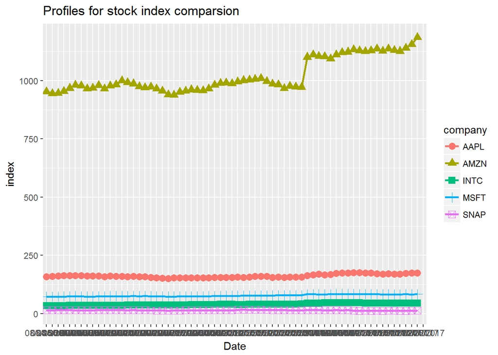

```r
library(ggplot2)
graph1 <- ggplot(data=analysis2,
          aes(x=Date, y=index, group=company)) +
          geom_point(size=3, aes(shape=company, color=company)) +
          geom_line(size=1, aes(color=company)) +
          ggtitle("Profiles for stock index comparsion")
graph1
```

# 5 day Moving Average

```r
# function for moving average
ma <- function(arr, n){
  res = arr
  for(i in n:length(arr)){
    res[i] = mean(arr[(i-n+1):i])
  }
  res
}

# Using close price to compare
aapl5 <- aapl3 %>% select(Date, Close)
colnames(aapl5) <- c("Date","AAPL")
amzn5 <- amzn3 %>% select(Date, Close)
colnames(amzn5) <- c("Date","AMZN")
intc5 <- intc3 %>% select(Date, Close)
colnames(intc5) <- c("Date","INTC")
msft5 <- msft3 %>% select(Date, Close)
colnames(msft5) <- c("Date","MSFT")
snap5 <- snap3 %>% select(Date, Close)
colnames(snap5) <- c("Date","SNAP")

# Calculate 5 days Moving Average
aapl5$AAPL_SMA <- ma(aapl5$AAPL, 5)
aapl6 <- aapl5 %>% select(Date, AAPL_SMA)

amzn5$AMZN_SMA <- ma(amzn5$AMZN, 5)
amzn6 <- amzn5 %>% select(Date, AMZN_SMA)

intc5$INTC_SMA <- ma(intc5$INTC, 5)
intc6 <- intc5 %>% select(Date, INTC_SMA)

msft5$MSFT_SMA <- ma(msft5$MSFT, 5)
msft6 <- msft5 %>% select(Date, MSFT_SMA)

snap5$SNAP_SMA <- ma(snap5$SNAP, 5)
snap6 <- snap5 %>% select(Date, SNAP_SMA)


# Group and visualization
x <- inner_join(aapl6,amzn6)
y <- inner_join(x,intc6)
z <- inner_join(y,msft6)
analysis3 <- inner_join(z,snap6)
analysis4 <- analysis3 %>% gather(company, index, 2:6)
head(analysis3)
```

```
##         Date AAPL_SMA AMZN_SMA INTC_SMA MSFT_SMA SNAP_SMA
## 1 11/26/2017       NA       NA       NA       NA       NA
## 2 11/24/2017   174.97 1186.000   44.750   83.260   12.970
## 3 11/22/2017   174.96 1156.160   44.650   83.110   12.620
## 4 11/21/2017   173.14 1139.490   44.940   83.720   12.340
## 5 11/20/2017       NA       NA       NA       NA       NA
## 6 11/17/2017   172.64 1147.568   44.718   83.004   12.666
```

```r
head(analysis4)
```

```
##         Date  company  index
## 1 11/26/2017 AAPL_SMA     NA
## 2 11/24/2017 AAPL_SMA 174.97
## 3 11/22/2017 AAPL_SMA 174.96
## 4 11/21/2017 AAPL_SMA 173.14
## 5 11/20/2017 AAPL_SMA     NA
## 6 11/17/2017 AAPL_SMA 172.64
```

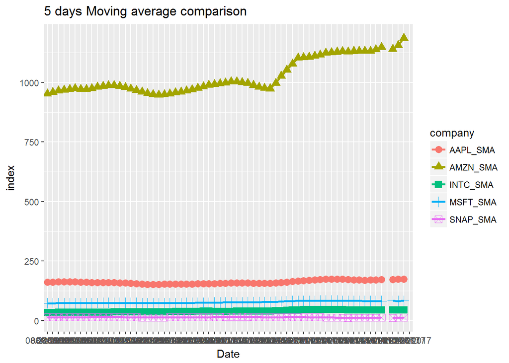

```r
# 5 days Moving average comparison
graph2 <- ggplot(data=analysis4,
          aes(x=Date, y=index, group=company)) +
          geom_point(size=3, aes(shape=company, color=company)) +
          geom_line(size=1, aes(color=company)) +
          ggtitle("5 days Moving average comparison")
graph2
```

# 20 days Moving Average

```r
# Using close price to compare
aapl7 <- aapl3 %>% select(Date, Close)
colnames(aapl7) <- c("Date","AAPL")
amzn7 <- amzn3 %>% select(Date, Close)
colnames(amzn7) <- c("Date","AMZN")
intc7 <- intc3 %>% select(Date, Close)
colnames(intc7) <- c("Date","INTC")
msft7 <- msft3 %>% select(Date, Close)
colnames(msft7) <- c("Date","MSFT")
snap7 <- snap3 %>% select(Date, Close)
colnames(snap7) <- c("Date","SNAP")

# Calculate 20 days Moving Average
aapl7$AAPL_SMA <- ma(aapl7$AAPL, 20)
aapl8 <- aapl7 %>% select(Date, AAPL_SMA)

amzn7$AMZN_SMA <- ma(amzn7$AMZN, 20)
amzn8 <- amzn7 %>% select(Date, AMZN_SMA)

intc7$INTC_SMA <- ma(intc7$INTC, 20)
intc8 <- intc7 %>% select(Date, INTC_SMA)

msft7$MSFT_SMA <- ma(msft7$MSFT, 20)
msft8 <- msft7 %>% select(Date, MSFT_SMA)

snap7$SNAP_SMA <- ma(snap7$SNAP, 20)
snap8 <- snap7 %>% select(Date, SNAP_SMA)


# Group and visualization
x <- inner_join(aapl8,amzn8)
y <- inner_join(x,intc8)
z <- inner_join(y,msft8)
analysis5 <- inner_join(z,snap8)
analysis6 <- analysis5 %>% gather(company, index, 2:6)
head(analysis5)
```

```
##         Date AAPL_SMA AMZN_SMA INTC_SMA MSFT_SMA SNAP_SMA
## 1 11/26/2017       NA       NA       NA       NA       NA
## 2 11/24/2017   174.97  1186.00    44.75    83.26    12.97
## 3 11/22/2017   174.96  1156.16    44.65    83.11    12.62
## 4 11/21/2017   173.14  1139.49    44.94    83.72    12.34
## 5 11/20/2017   169.98  1126.31    44.62    82.53    12.41
## 6 11/17/2017   170.15  1129.88    44.63    82.40    12.99
```

```r
head(analysis6)
```

```
##         Date  company  index
## 1 11/26/2017 AAPL_SMA     NA
## 2 11/24/2017 AAPL_SMA 174.97
## 3 11/22/2017 AAPL_SMA 174.96
## 4 11/21/2017 AAPL_SMA 173.14
## 5 11/20/2017 AAPL_SMA 169.98
## 6 11/17/2017 AAPL_SMA 170.15
```

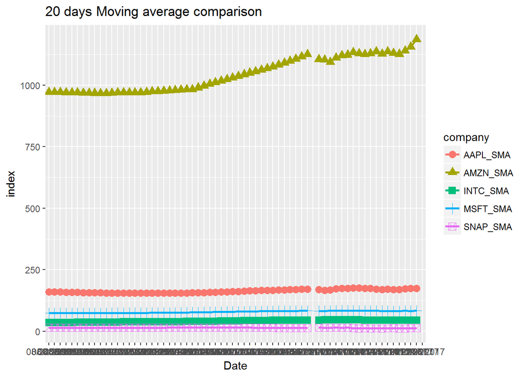

```r
# 20 days Moving average comparison
graph2 <- ggplot(data=analysis6,
          aes(x=Date, y=index, group=company)) +
          geom_point(size=3, aes(shape=company, color=company)) +
          geom_line(size=1, aes(color=company)) +
          ggtitle("20 days Moving average comparison")
graph2
```

# visualization for 3 months

```
## geom_path: Each group consists of only one observation. Do you need to
## adjust the group aesthetic?
```

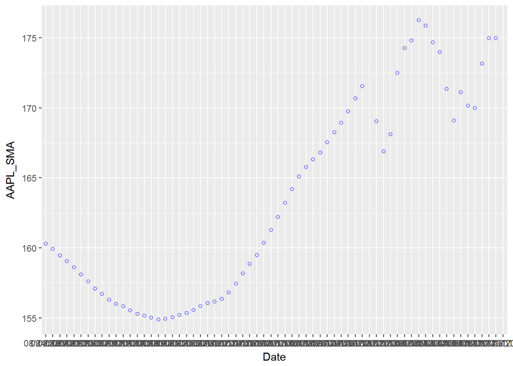

```r
library(ggplot2)

aapl9 <- subset(aapl8, Date < "12-01-2017" & Date > "08-22-2017")
x <- ggplot(data = aapl9,  aes(x=Date, y=AAPL_SMA)) + geom_line(col="blue") + geom_point(col="blue", pch=1)
x
```

```
## geom_path: Each group consists of only one observation. Do you need to
## adjust the group aesthetic?
```

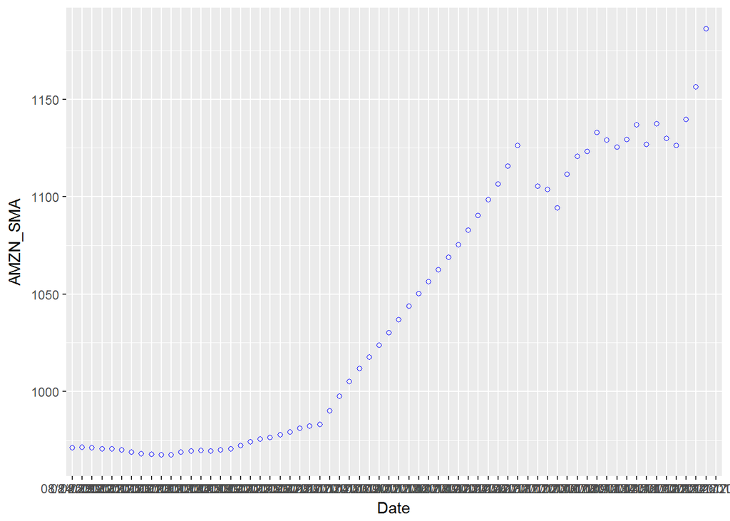

```r
amzn9 <- subset(amzn8, Date < "12-01-2017" & Date > "08-22-2017")
x <- ggplot(data = amzn9,  aes(x=Date, y=AMZN_SMA)) + geom_line(col="blue") + geom_point(col="blue", pch=1)
x
```

```
## geom_path: Each group consists of only one observation. Do you need to
## adjust the group aesthetic?
```

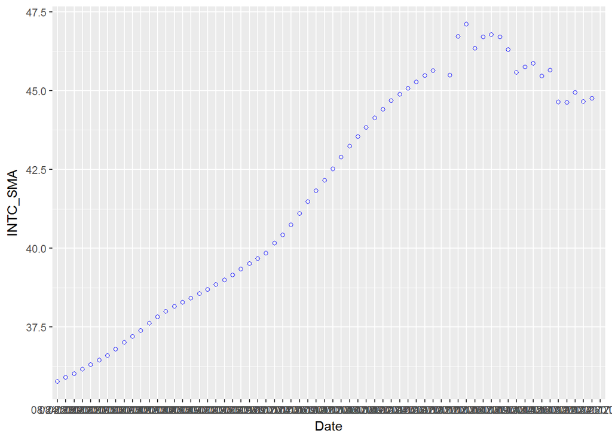

```r
intc9 <- subset(intc8, Date < "12-01-2017" & Date > "08-22-2017")
x <- ggplot(data = intc9,  aes(x=Date, y=INTC_SMA)) + geom_line(col="blue") + geom_point(col="blue", pch=1)
x
```

```
## geom_path: Each group consists of only one observation. Do you need to
## adjust the group aesthetic?
```

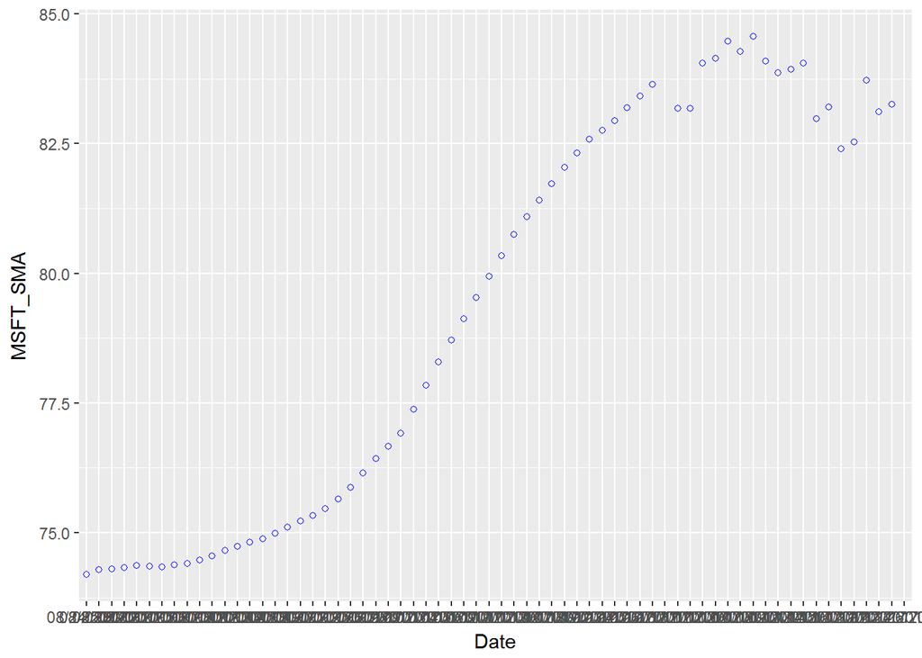

```r
msft9 <- subset(msft8, Date < "12-01-2017" & Date > "08-22-2017")
x <- ggplot(data = msft9,  aes(x=Date, y=MSFT_SMA)) + geom_line(col="blue") + geom_point(col="blue", pch=1)
x
```

```
## geom_path: Each group consists of only one observation. Do you need to
## adjust the group aesthetic?
```

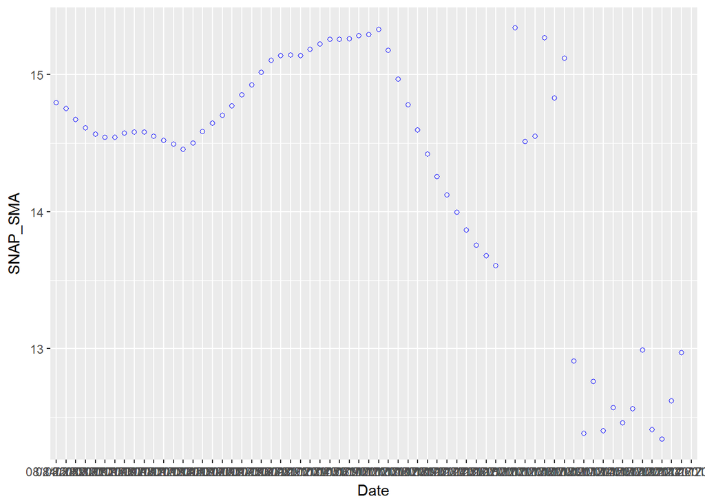

```r
snap9 <- subset(snap8, Date < "12-01-2017" & Date > "08-22-2017")
x <- ggplot(data = snap9,  aes(x=Date, y=SNAP_SMA)) + geom_line(col="blue") + geom_point(col="blue", pch=1)
x
```

# Market Price

```r
library(rvest)
library(XML)

sym <- function(i){
url <- paste('http://www.nasdaq.com/symbol/',i,'/',sep="")
html <- read_html(url)
body_text <- html %>%
        html_nodes("#qwidget_lastsale") %>%
        html_text()

body_text <- as.numeric(sub('\\$','',body_text))
print(body_text)
}

# use "amzn" as example to run program
sym('amzn')
```

```
## [1] 1186.41
```

# Create new trade file into CSV

```r
# create new dataframe
trade <-data.frame("Side"=character(), "Ticker"=character(), "Quantity"=integer(0), "Price"=integer(0), "Date"=character(),stringsAsFactors = FALSE)



# save dataframe as csv file
write.table(trade, file = "trade.csv", sep = ",", col.names = NA, qmethod = "double")
read.table("trade.csv", header = TRUE, sep = ",")
```

```
## [1] X        Side     Ticker   Quantity Price    Date
## <0 rows> (or 0-length row.names)
```

# Add sell or buy record into CSV file

```r
library(dplyr)
#import csv
x <- read.csv("trade.csv", header = TRUE, sep = ",")

############### in case to ask for buy or sell, and check the balance


#side <- readline(prompt="Buy or Sell: ")
#ticker <- readline(prompt="ticker: ")
#quantity <- readline(prompt="quantity: ")

# convert character into integer
#quantity <- as.integer(quantity)

#print(paste("You", side,quantity,"stock of", ticker, "."))

#marketvalue = sym(ticker)
#buyvalue = marketvalue * quantity

#if (side == 'buy'){
#  if (cashbal < buyvalue){
#    print("No cash to buy!")
#  } else {
#    x[nrow(x) +1,] <- c(nrow(x)+1, side , ticker , quantity, marketvalue, Sys.Date())
#  }
#}

###########

# add new transaction(example buy and sell, amzn, 30, 1000.46)
x[nrow(x) +1,] <- c(nrow(x)+1,'buy', 'amzn', 30, 1000.46, txtdate)
x[nrow(x) +1,] <- c(nrow(x)+1,'sell', 'amzn', 15, 1100.00, txtdate)

# tidy dataframe
trade = select(x, -1)


# re-write and save over the previous data
write.table(trade, file = "trade.csv", sep = ",", col.names = NA, qmethod = "double")
read.table("trade.csv", header = TRUE, sep = ",")
```

```
##   X Side Ticker Quantity   Price       Date
## 1 1  buy   amzn       30 1000.46 11/26/2017
## 2 2 sell   amzn       15 1100.00 11/26/2017
```

# Balance of stock

```r
# check position
blotter <- read.csv("trade.csv", header = TRUE, sep = ",")
w =nrow(blotter)
w
```

```
## [1] 2
```

```r
# Postition
q <- unique(blotter$Ticker)

b=0
d=0
e=0
f=0
balance <-data.frame("Ticker"=character(), "Quantity"=integer(0), "Price"=integer(0),stringsAsFactors = FALSE)


for (j in q){
for (i in 1:w){
if(blotter$Side[i] == 'buy' & blotter$Ticker[i] == j){
  a = sum(blotter$Quantity[i])
  b = b + a
  e = e + blotter$Price[i]*blotter$Quantity[i]
  }
if(blotter$Side[i] == 'sell' & blotter$Ticker[i] == j){
  c = sum(blotter$Quantity[i])
  d = d + c
  f = f + blotter$Price[i]*blotter$Quantity[i]
}
  bal = b-d
  avg = e/a
  print(bal)

}
balance <- rbind(balance, data.frame("Ticker"=q, "Quantity"=bal, "Price"=avg))
balance <- na.omit(balance)
}
```

```
## [1] 30
## [1] 15
```

```r
balance
```

```
##   Ticker Quantity   Price
## 1   amzn       15 1000.46
```

# P/L

```r
#z
pl <-data.frame("Ticker"=character(), "Position"=integer(0), "Market"=integer(0), "WAP"=integer(0), "UPL"=integer(0), "RPL"=integer(0),stringsAsFactors = FALSE)

# Ticker and Market price
h = nrow(balance)

k <- unique(balance$Ticker)
upl = 0
rpl = 0

for (i in h){
  l = balance$Ticker[i]
  m = balance$Quantity[i]
  n = balance$Price[i]
  y <- as.vector(l)
  o = sym(y)
  marketp = o
  if (marketp > n){
    upl = (marketp-n)*m
    rpl = 0
    upl
  }else{
    rpl = (n-marketp)*m
    upl = 0
    rpl
  }
  #total = upl + rpl
  #share = m/sum(pl$Position)
  #dollar = marketp/sum(pl$Market)
}
```

```
## [1] 1186.41
```

```r
pl <- rbind(pl, data.frame("Ticker"=k, "Position"=m, "Market"=o, "WAP"=n, "UPL"=upl, "RPL"=rpl))

total = upl + rpl
share = m/sum(pl$Position)
dollar = marketp/sum(pl$Market)

pl$Total = total
pl$Allocationshare = share
pl$Allocationmarket = dollar
pl
```

```
##   Ticker Position  Market     WAP     UPL RPL   Total Allocationshare
## 1   amzn       15 1186.41 1000.46 2789.25   0 2789.25               1
##   Allocationmarket
## 1                1
```

```r
# WAP
```

# check cashbalance

```r
blotter <- read.csv("trade.csv", header = TRUE, sep = ",")

w =nrow(blotter)

z = 100000
p = 0
q = 0
for(i in 1:w){
  if (blotter$Side[i] == 'buy'){
    p = p + blotter$Price[i]*blotter$Quantity[i]
  }
  if (blotter$Side[i] == 'sell'){
    q = q + blotter$Price[i]*blotter$Quantity[i]
  }
}
cashbal = z-p+q
cashbal
```

```
## [1] 86486.2
```